# US Census Data Write-up

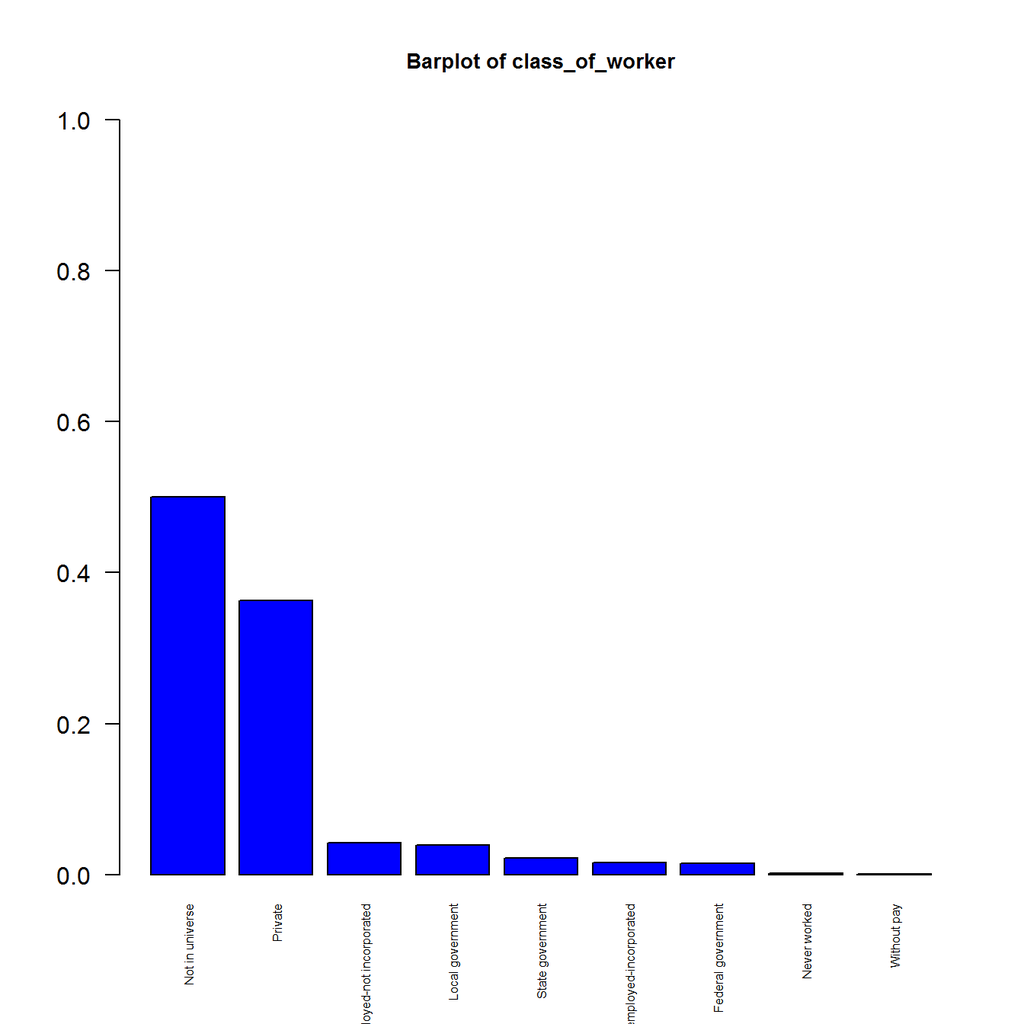

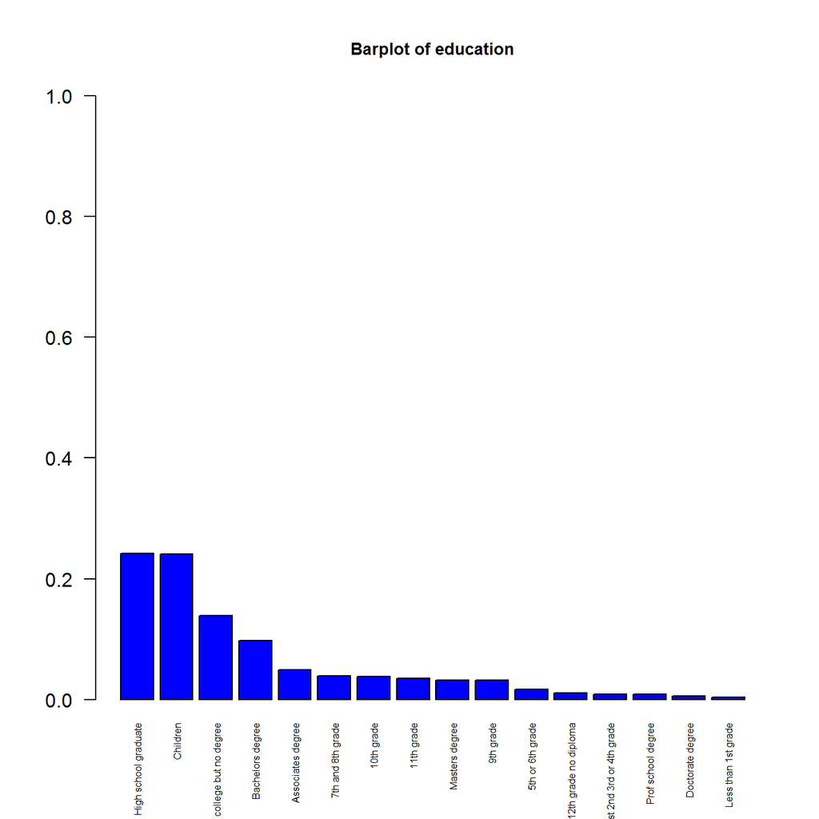

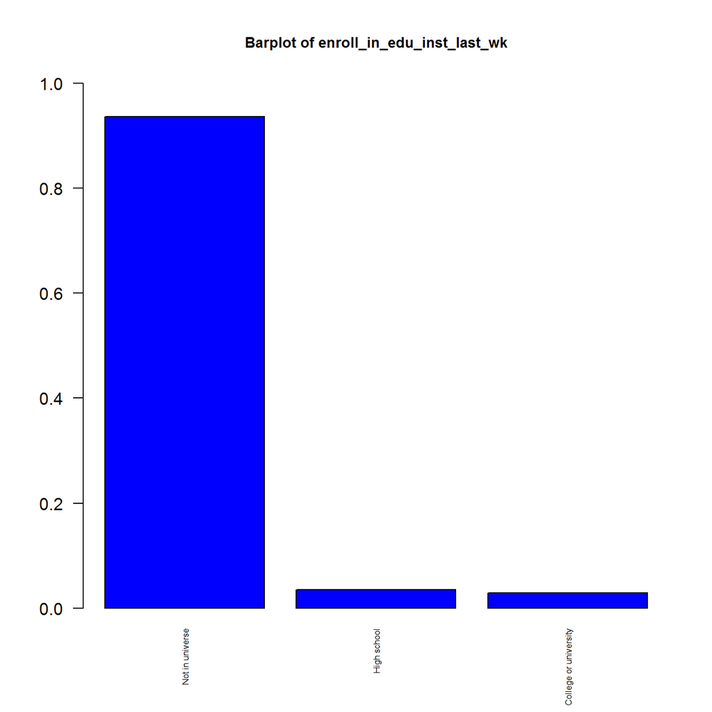

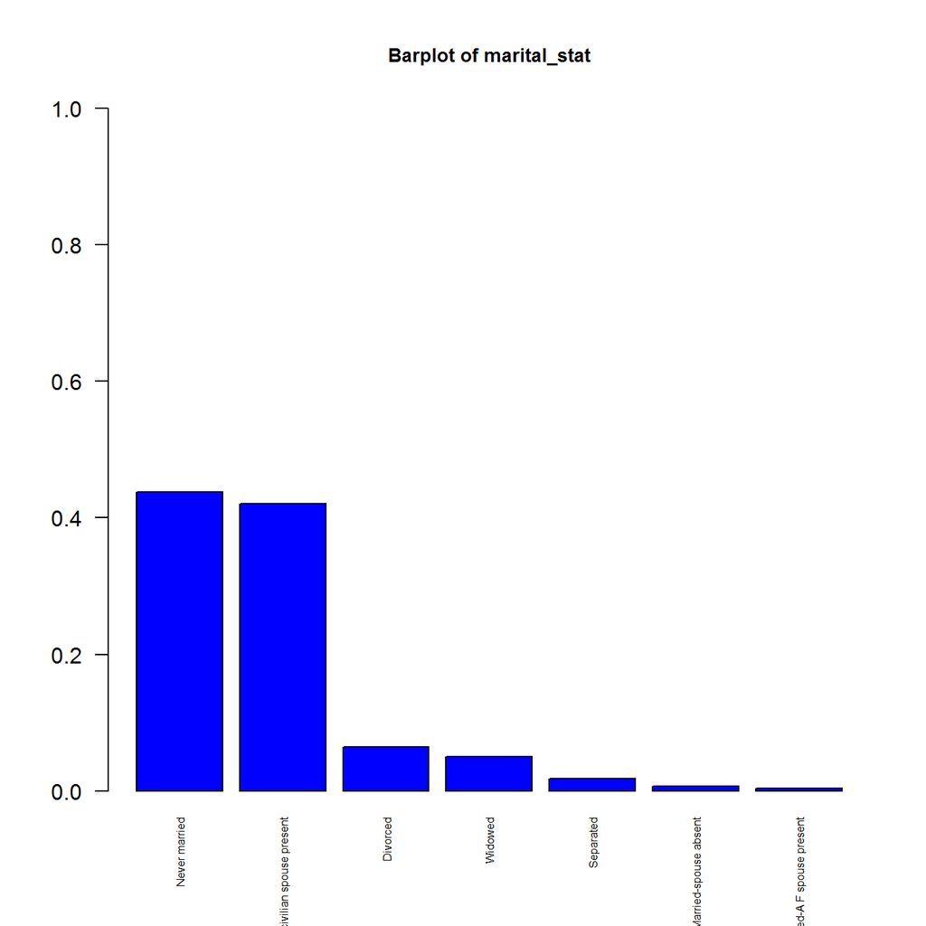

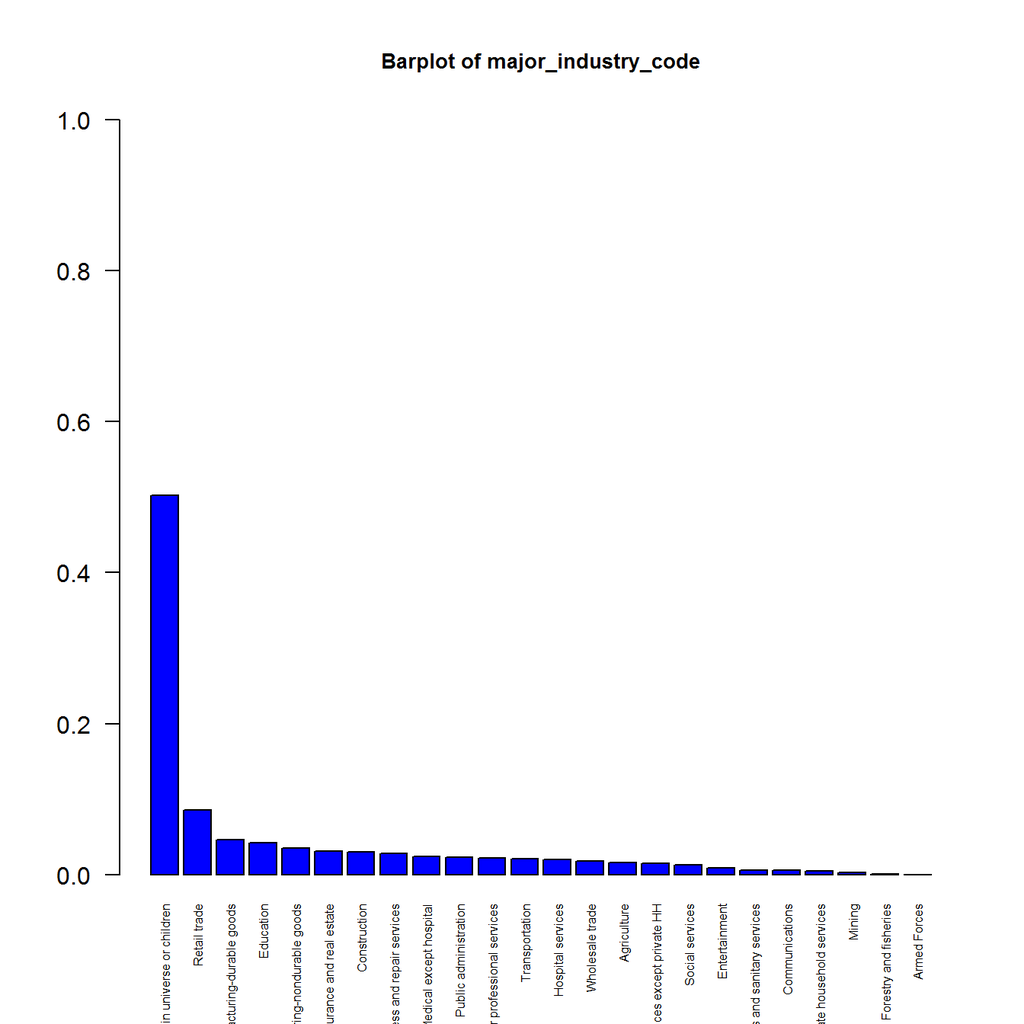

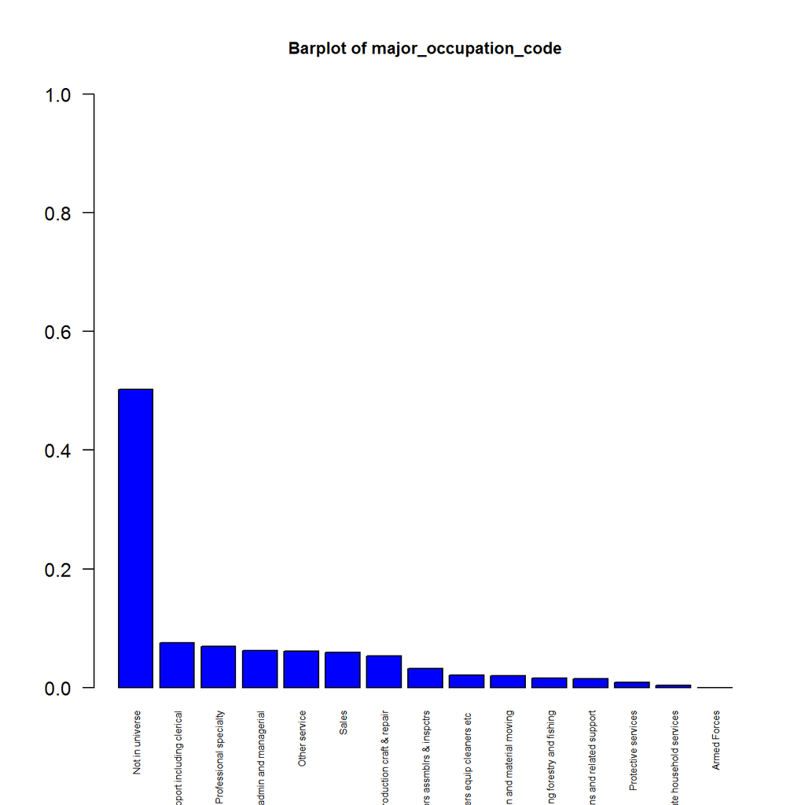

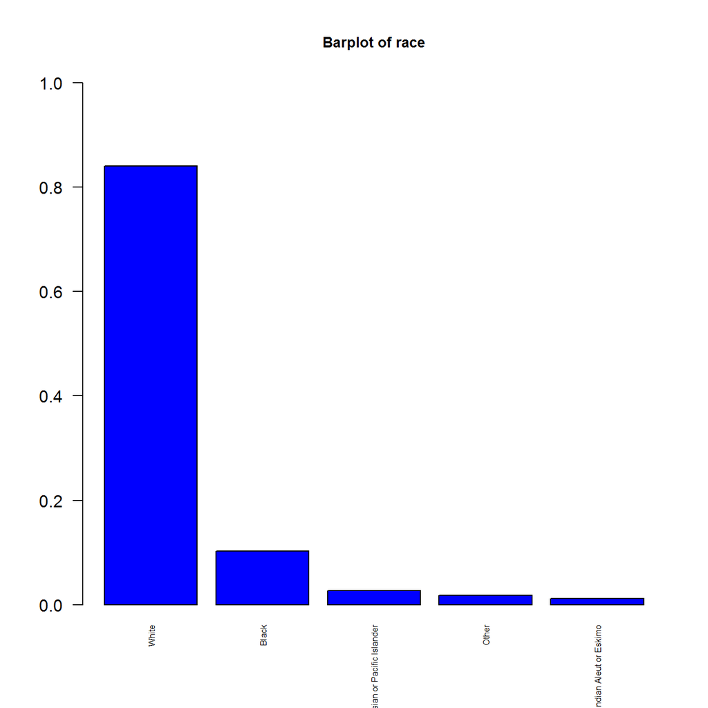

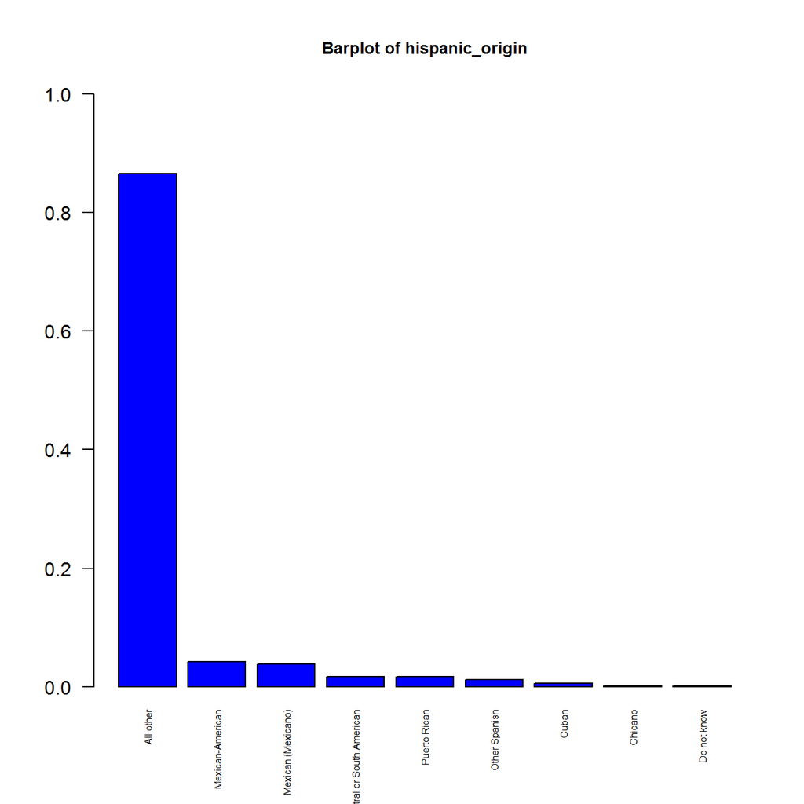

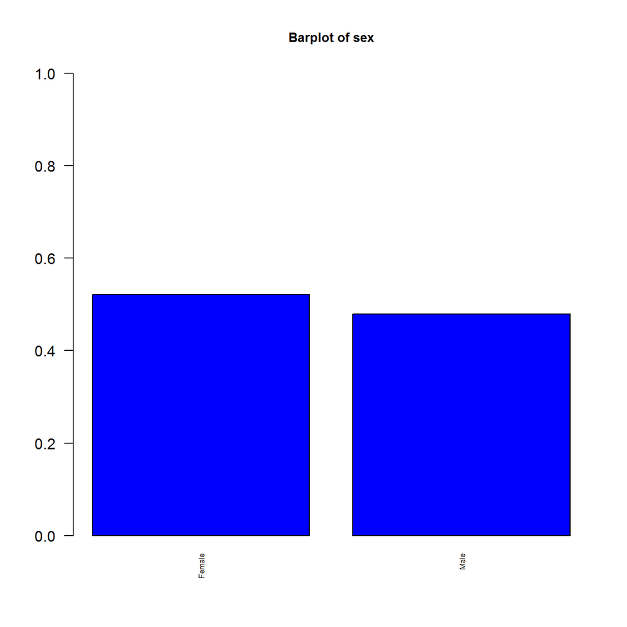

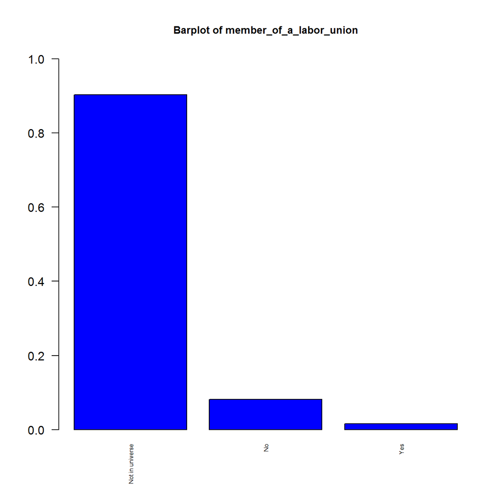

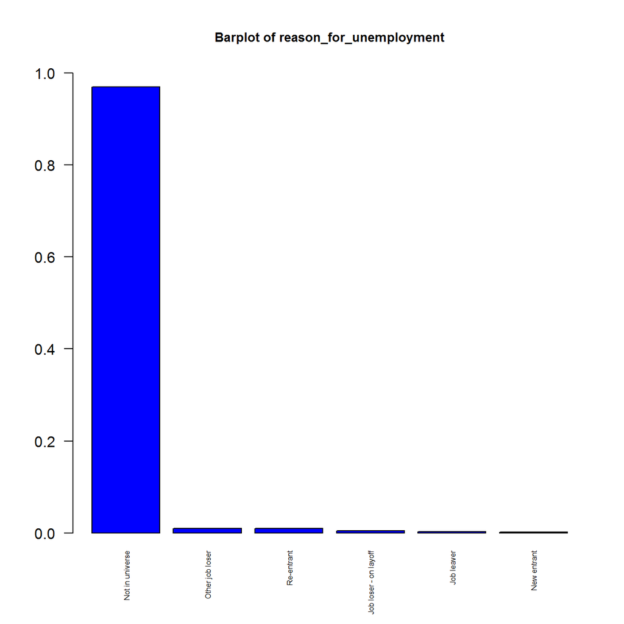

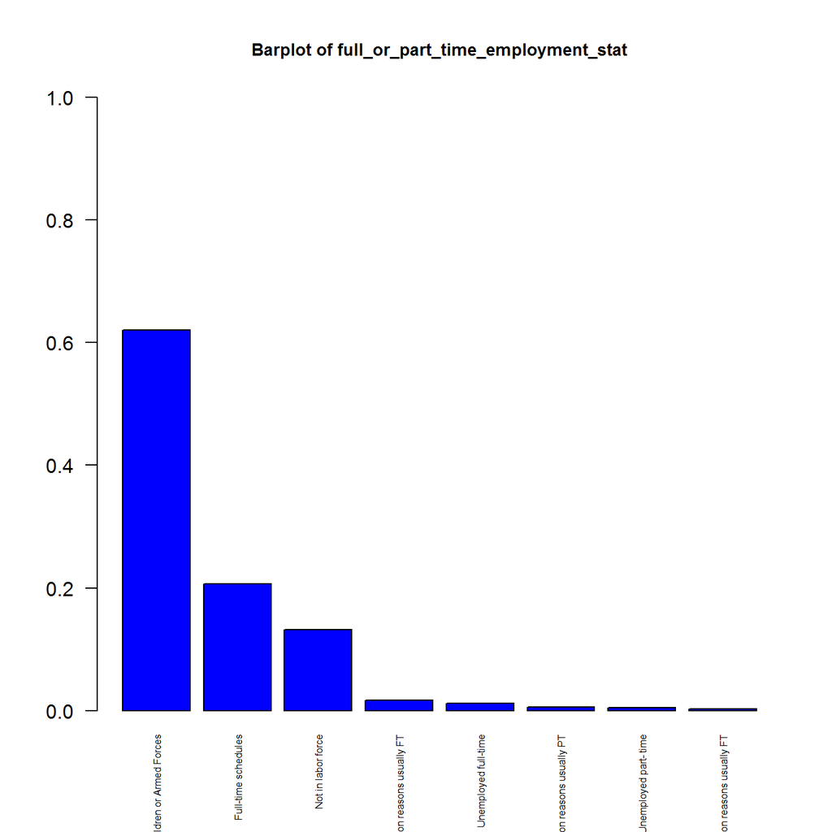

[16 more figures not shown]

```r
load("./proc_files/data1")
load("./proc_files/help_data1")
library(ggplot2)

n_train <- help_data$n_train
for (var in help_data$fact_var) {
    barplot(table(data[1:n_train, var])[order(table(data[1:n_train, var]), decreasing = T)]/n_train,
        main = paste("Barplot of", var), horiz = F, col = "blue", ylim = c(0,
            1), las = 2, cex.main = 0.85, cex.names = 0.5)
}
```

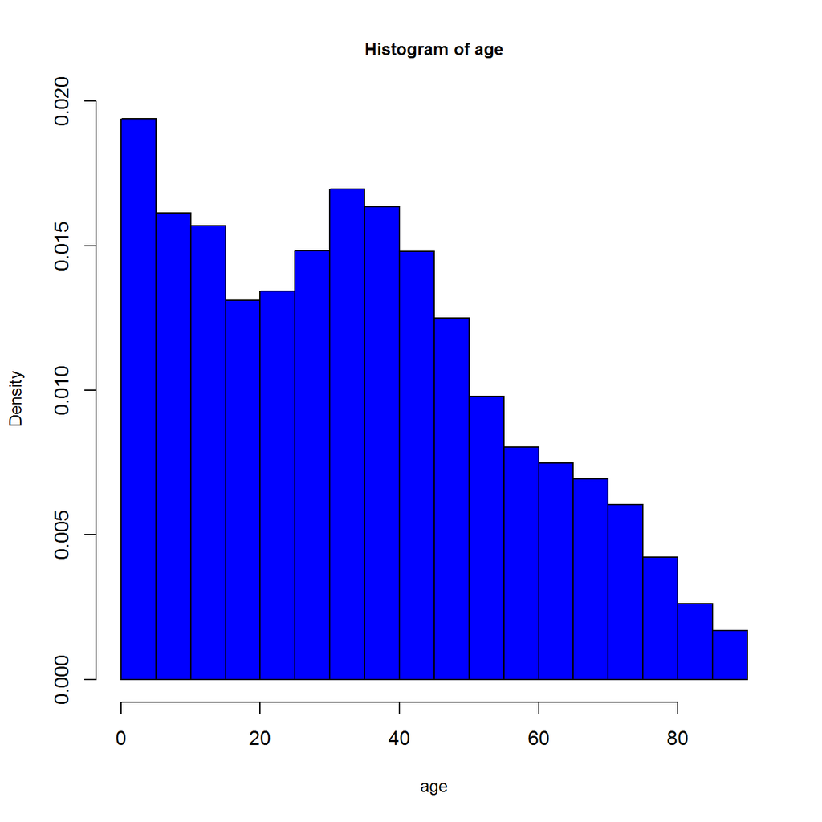

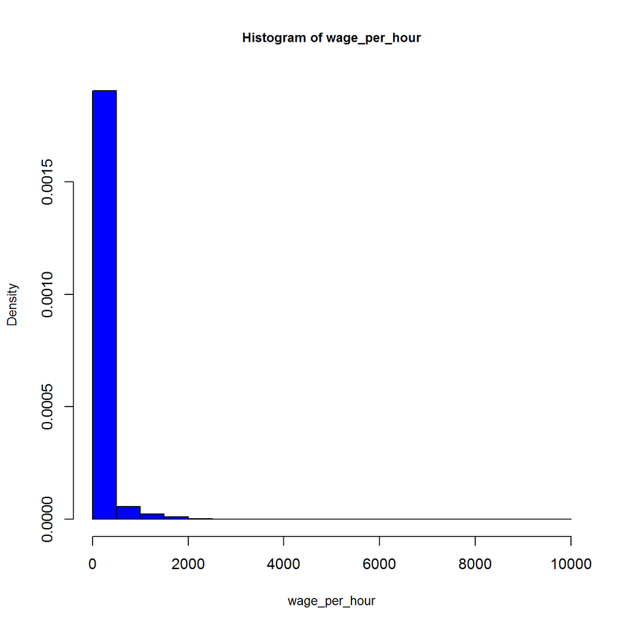

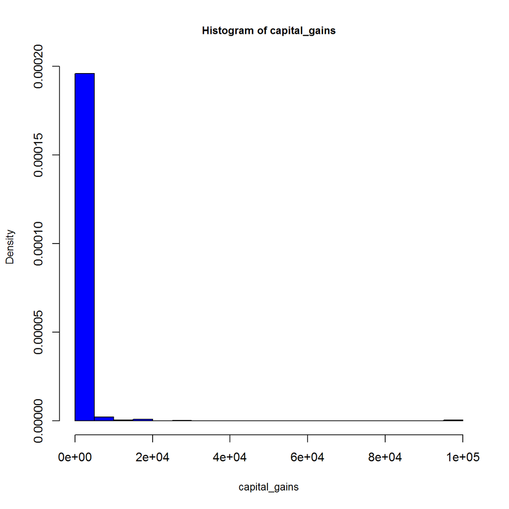

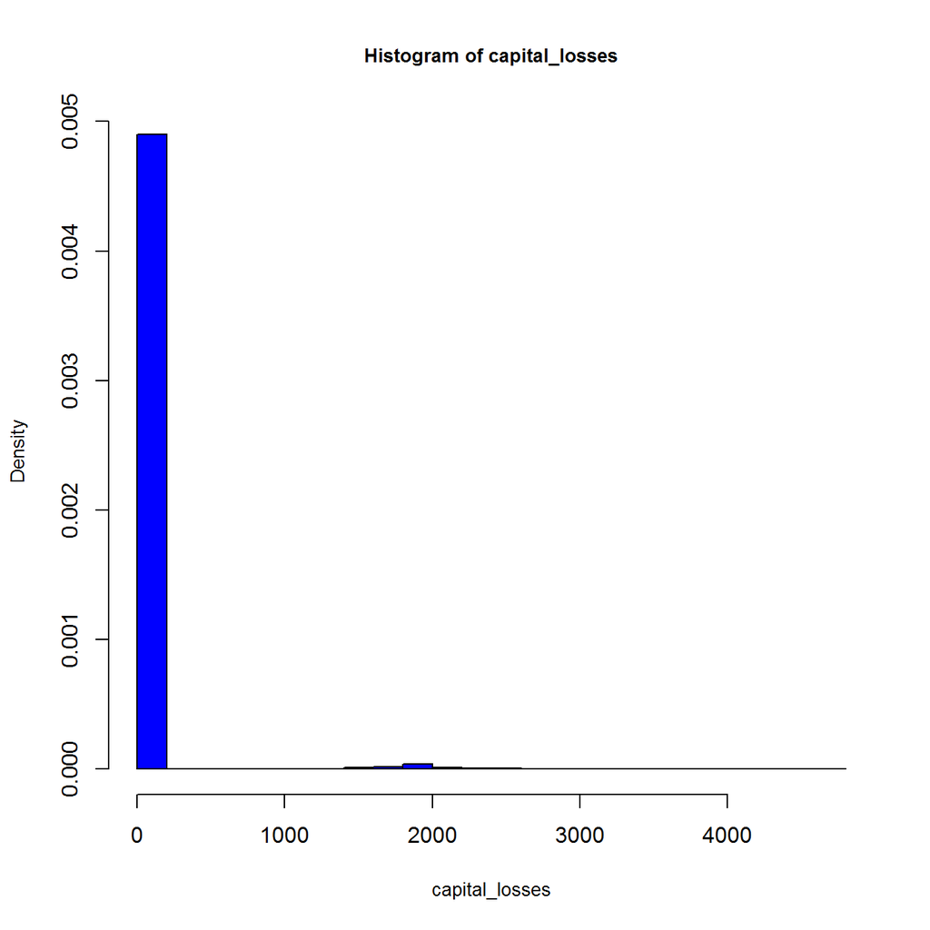

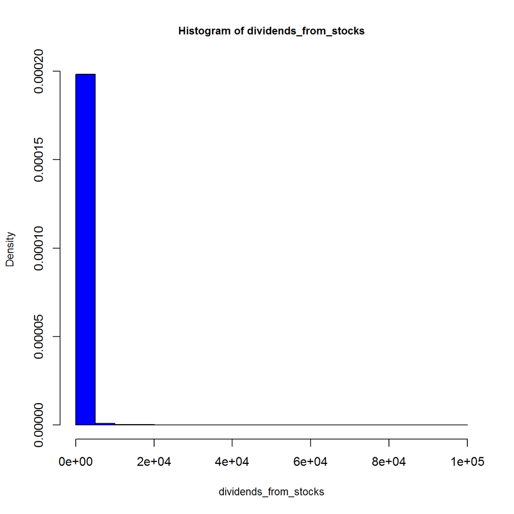

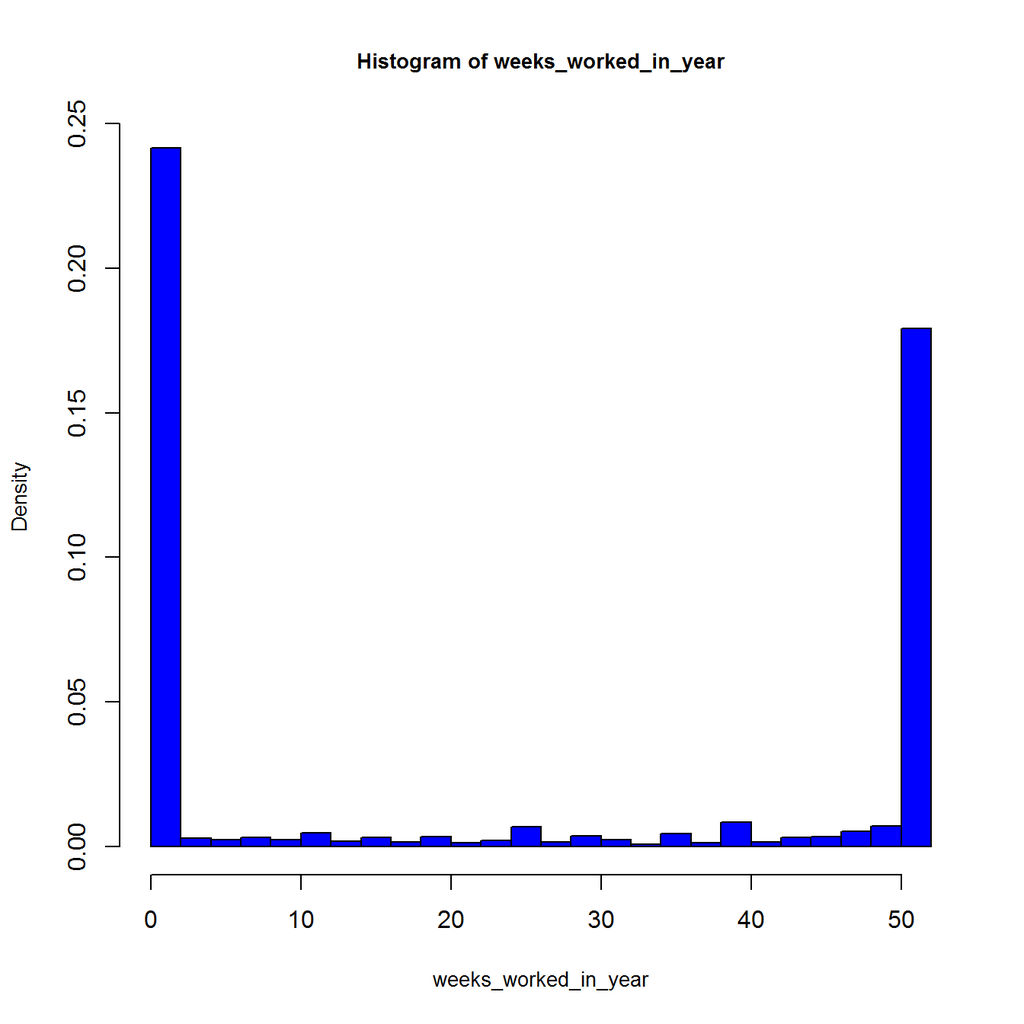

```r
for (var in help_data$contin_var) {
    hist(data[1:n_train, var], main = paste("Histogram of", var), col = "blue",
        freq = F, xlab = var, cex.main = 0.85, cex.lab = 0.85)
}
```

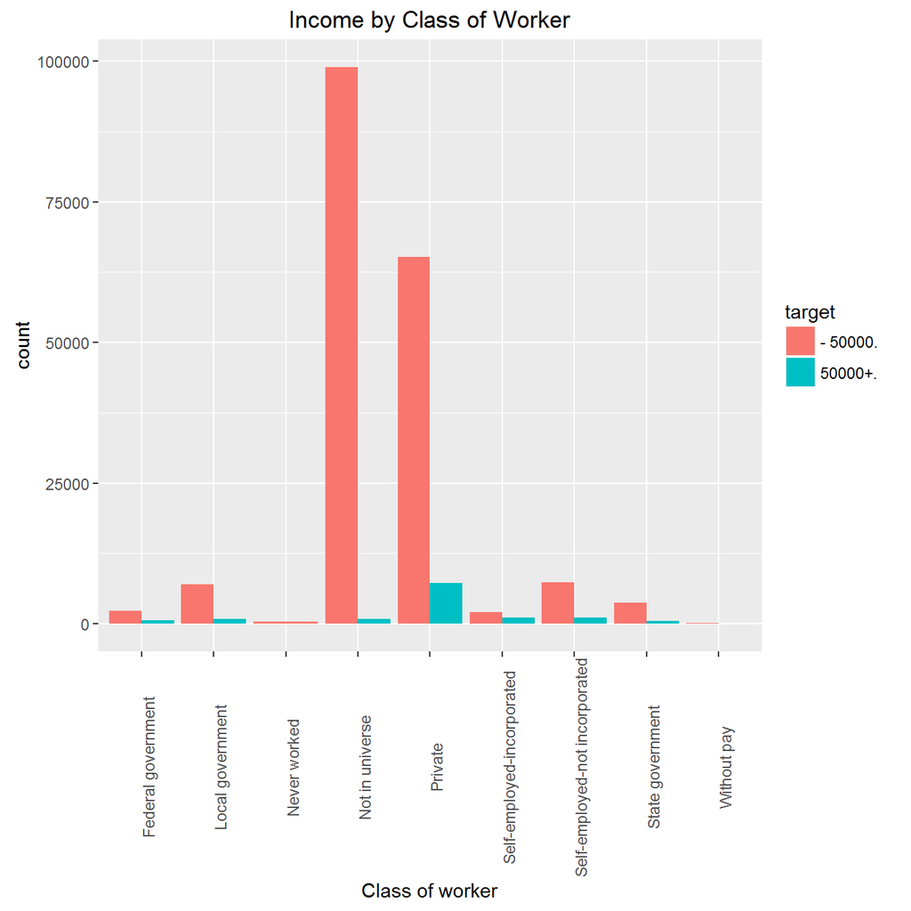

```r
ggplot(data[1:n_train, ], aes(x = class_of_worker, fill = target)) + geom_bar(position = "dodge") +
    ggtitle("Income by Class of Worker") + ylab("count") + xlab("Class of worker") +
    theme(axis.text.x = element_text(angle = 90))
```

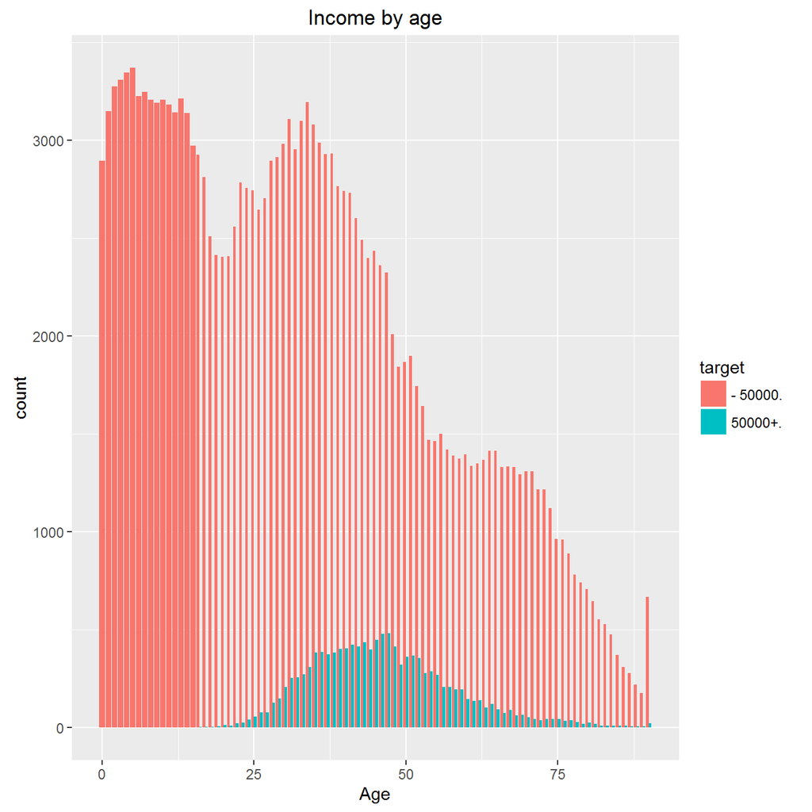

```r
ggplot(data[1:n_train, ], aes(x = age, fill = target)) + geom_bar(position = "dodge") +
    ggtitle("Income by age") + ylab("count") + xlab("Age")
```

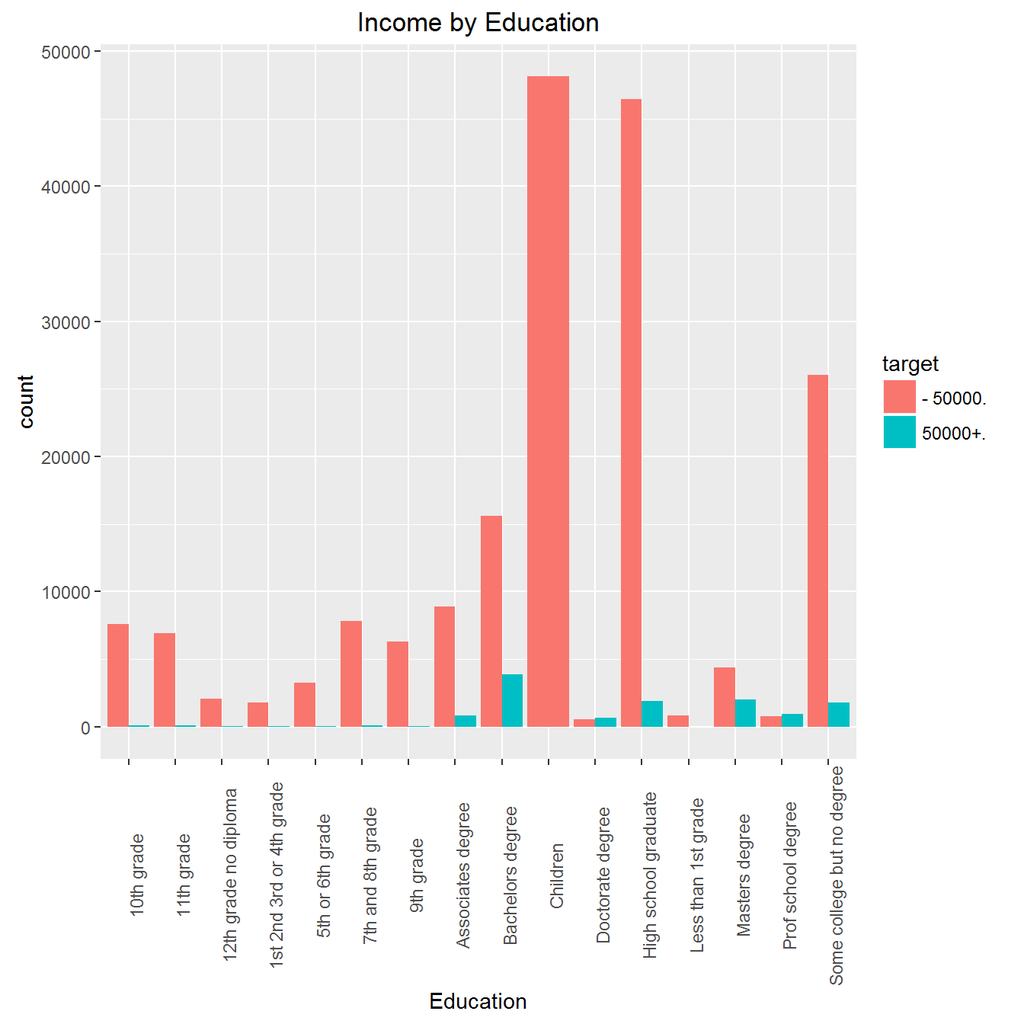

```r
ggplot(data[1:n_train, ], aes(x = education, fill = target)) + geom_bar(position = "dodge") +
    ggtitle("Income by Education") + ylab("count") + xlab("Education") + theme(axis.text.x = element_text(angle = 90))
```

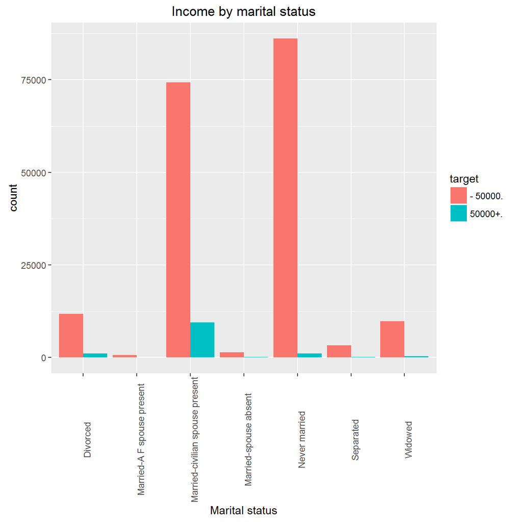

```r
ggplot(data[1:n_train, ], aes(x = marital_stat, fill = target)) + geom_bar(position = "dodge") +
    ggtitle("Income by marital status") + ylab("count") + xlab("Marital status") +
    theme(axis.text.x = element_text(angle = 90))
```

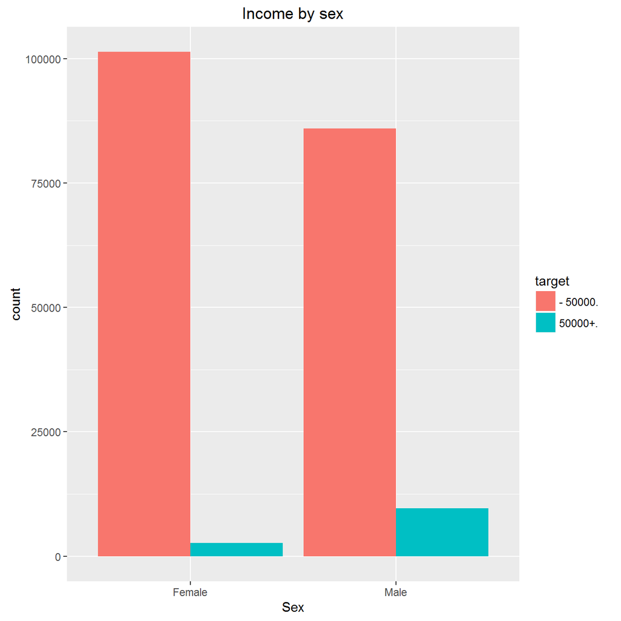

```r
ggplot(data[1:n_train, ], aes(x = sex, fill = target)) + geom_bar(position = "dodge") +
    ggtitle("Income by sex") + ylab("count") + xlab("Sex") + theme(axis.text.x = element_text(angle = 0))
```

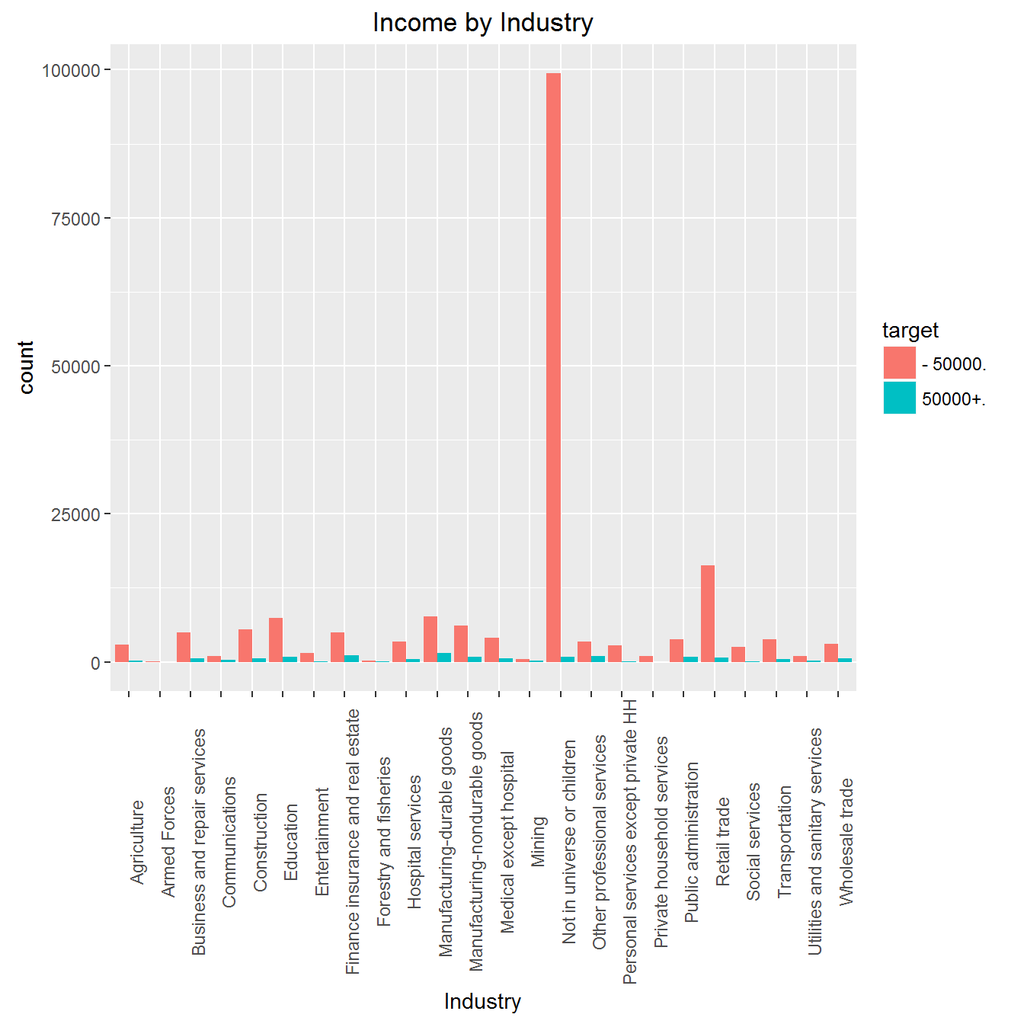

```r
ggplot(data[1:n_train, ], aes(x = major_industry_code, fill = target)) + geom_bar(position = "dodge") +
    ggtitle("Income by Industry") + ylab("count") + xlab("Industry") + theme(axis.text.x = element_text(angle = 90))
```

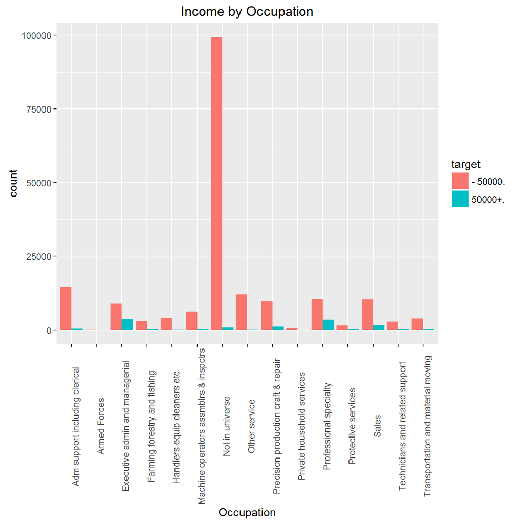

```r
ggplot(data[1:n_train, ], aes(x = major_occupation_code, fill = target)) + geom_bar(position = "dodge") +
    ggtitle("Income by Occupation") + ylab("count") + xlab("Occupation") + theme(axis.text.x = element_text(angle = 90))
```

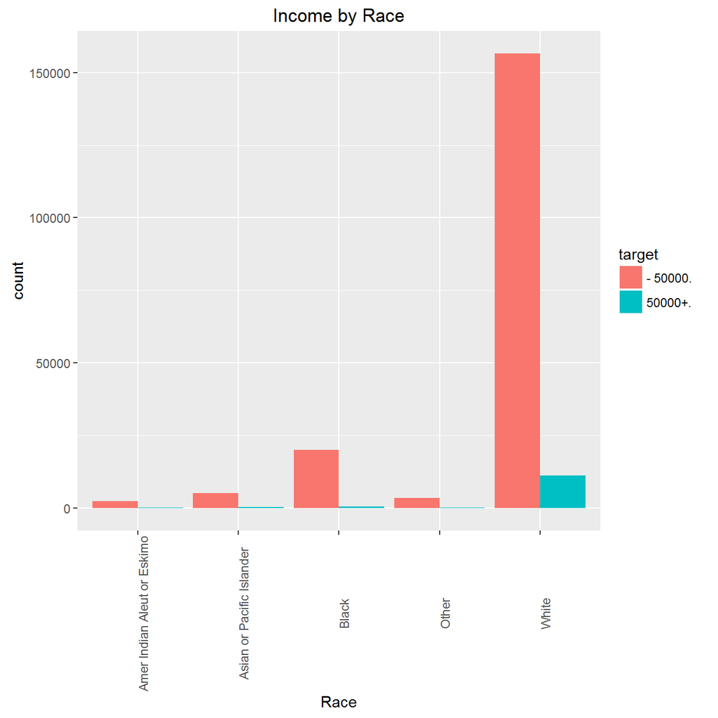

```r
ggplot(data[1:n_train, ], aes(x = race, fill = target)) + geom_bar(position = "dodge") +
    ggtitle("Income by Race") + ylab("count") + xlab("Race") + theme(axis.text.x = element_text(angle = 90))
```

## Models

In order to model the income variable, the following reasoning will be applied:  
- learn a subset of important variables using random forest  
- compare two classification models with the latter subset (eliminate noise and redundancy): random forest and generalized boosted regression model.

In order to handle this unbalanced dataset, a rigorous model would use an oversampling technique such as Synthetic Minority Over-sampling Technique (NV Chawla - 2002), but it’s out of the scope of this evaluation.

### Feature selection

Random forests can assess variable importance and out-of-bag error internally, it can be used to obtain a relevant feature subset.

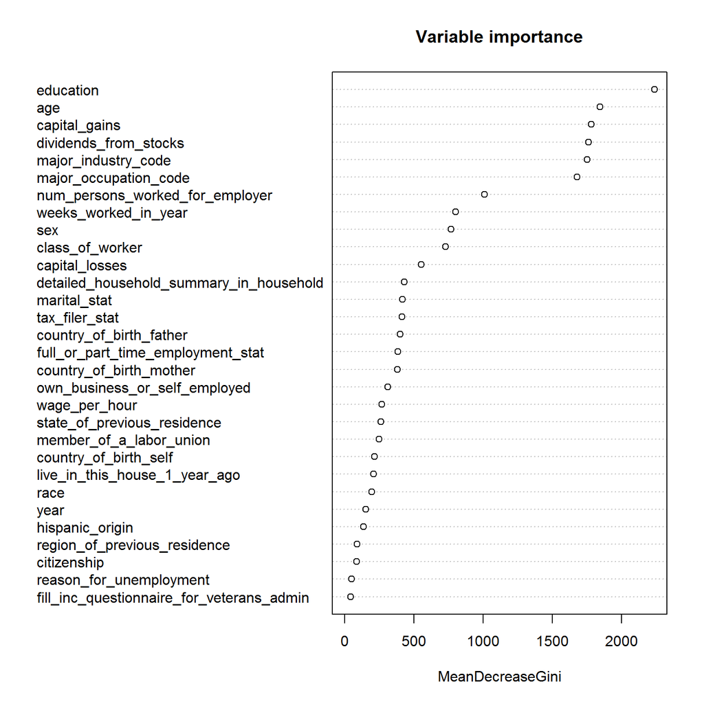

```r
library(randomForest)
load("./proc_files/data1")
load("./proc_files/help_data1")

data$target<-as.factor(as.integer(data$target)-1)
rf1<-randomForest(target~.,data=data[1:help_data$n_train,],importance=T,ntree=100)
varImpPlot(rf1,main="Variable importance",type=2)
```

```r
load("./proc_files/help_data1")
library(caret)
confusionMatrix(help_data$preds_rf1,data$target[1:help_data$n_train],positive="1")
```

```
## Confusion Matrix and Statistics
##
##           Reference
## Prediction      0      1
##          0 187243  11060
##          1     55   1165
##
##                Accuracy : 0.9443
##                  95% CI : (0.9433, 0.9453)
##     No Information Rate : 0.9387
##     P-Value [Acc > NIR] : < 2.2e-16
##
##                   Kappa : NA
##  Mcnemar's Test P-Value : < 2.2e-16
##
##             Sensitivity : 0.095297
##             Specificity : 0.999706
##          Pos Pred Value : 0.954918
##          Neg Pred Value : 0.944227
##              Prevalence : 0.061271
##          Detection Rate : 0.005839
##    Detection Prevalence : 0.006115
##       Balanced Accuracy : 0.547501
##
##        'Positive' Class : 1
##
```

```r
#F1-Score
r<-confusionMatrix(help_data$preds_rf1,data$target[1:help_data$n_train],positive="1")$byClass[1]
p<-confusionMatrix(help_data$preds_rf1,data$target[1:help_data$n_train],positive="1")$byClass[3]
paste("F1-score:",(2*p*r)/(p+r))
```

```
## [1] "F1-score: 0.173298624023801"
```

The accuracy is high (accuracy paradox). However, the confusion matrix, the large amount of false negatives (low recall) and the low F1-score show the difficulty of this model at predicting the income class.

### Random forest with the subset of relevant features

Now we can use the subset of features obtained in the last step to try again a random forest:

```r
feat_sub<-c("education","major_occupation_code","age","major_industry_code",
            "dividends_from_stocks","capital_gains","target")
rf2<-randomForest(target~.,data=data[1:help_data$n_train,feat_sub],importance=T,ntree=100)
confusionMatrix(help_data$preds_rf2,data$target[1:help_data$n_train],positive="1")
```

```
## Confusion Matrix and Statistics
##
##           Reference
## Prediction      0      1
##          0 186666   5798
##          1    632   6427
##
##                Accuracy : 0.9678
##                  95% CI : (0.967, 0.9685)
##     No Information Rate : 0.9387
##     P-Value [Acc > NIR] : < 2.2e-16
##
##                   Kappa : NA
##  Mcnemar's Test P-Value : < 2.2e-16
##
##             Sensitivity : 0.52573
##             Specificity : 0.99663
##          Pos Pred Value : 0.91047
##          Neg Pred Value : 0.96987
##              Prevalence : 0.06127
##          Detection Rate : 0.03221
##    Detection Prevalence : 0.03538
##       Balanced Accuracy : 0.76118
##
##        'Positive' Class : 1
##
```

```r
#F1-Score
r<-confusionMatrix(help_data$preds_rf2,data$target[1:help_data$n_train],positive="1")$byClass[1]
p<-confusionMatrix(help_data$preds_rf2,data$target[1:help_data$n_train],positive="1")$byClass[3]
paste("F1-score:",(2*p*r)/(p+r))
```

```
## [1] "F1-score: 0.666562953744037"
```

The model performs better, as shown by the increases of recall and harmonic mean recall/precision.

### Generalized Boosting Regression Model

Following the same reasoning as before, a generalized boosting regression model has been tried on both whole set and subset of features. Due to caret package inefficiency on my machine, I wrote my own parallelized routine (gbm_grid) for finding the best parameters using a grid search with cross-validation.  
The classifier using the subset of features performs better, but the recall (0.23) and F1-score (0.29) are lower than the ones obtained using random forest with the feature subset.

## Test

Random forest appears to be the best model on the training set. But the following shows its lower performance on the independent test dataset.

```r
test_preds<-predict(rf2,newdata=data[-c(1:help_data$n_train),feat_sub],
                    type="response")
confusionMatrix(test_preds,data$target[-c(1:help_data$n_train)],positive="1")
```

```
## Confusion Matrix and Statistics
##
##           Reference
## Prediction     0     1
##          0 78981  3256
##          1   875  1921
##
##                Accuracy : 0.9514
##                  95% CI : (0.95, 0.9529)
##     No Information Rate : 0.9391
##     P-Value [Acc > NIR] : < 2.2e-16
##
##                   Kappa : NA
##  Mcnemar's Test P-Value : < 2.2e-16
##
##             Sensitivity : 0.37106
##             Specificity : 0.98904
##          Pos Pred Value : 0.68705
##          Neg Pred Value : 0.96041
##              Prevalence : 0.06088
##          Detection Rate : 0.02259
##    Detection Prevalence : 0.03288
##       Balanced Accuracy : 0.68005
##
##        'Positive' Class : 1
##
```

```r
r<-confusionMatrix(test_preds,data$target[-c(1:help_data$n_train)],positive="1")$byClass[1]
p<-confusionMatrix(test_preds,data$target[-c(1:help_data$n_train)],positive="1")$byClass[3]
paste("F1-score:",(2*p*r)/(p+r))
```

```
## [1] "F1-score: 0.481876332622601"
```

## Notes

The most difficult steps have been for me to understand the data set and its variables (everything was not clearly explicited in the metadata file) and to find a way of how to get a first quick-and-dirty model. Performing all these steps in some hours has been challenging but interesting.

As noted in the instructions, I spent several hours on the data set (not days). If I had to build a pure model, I would focus on these points:

- careful preprocessing and feature engineering
- try generating synthetic samples (using *Synthetic Minority Over-sampling Technique* for instance)
- try **penalized logistic regression** (with L1 penalization)
- diagnose bias Vs variance using learning curves
- try other ensembling models such as extreme gradient boosting
- improve tuning parameters process
- try model ensembling with the best models obtained
- try other perspectives, like **anomaly detection**